# Lab2 - Checkpoint 3

```r
respostas = read_csv(here::here("data/respostas-merepresenta-2016.csv"),
                     col_types = cols(.default = col_character(),
                                      nota_partido = col_integer(),
                                      votos_recebidos = col_integer()))

# A versão long (em vez de wide) dos dados facilita muito pro ggplot:
respostas_long =
    respostas %>%
    gather(key = "tema",
           value = "resposta",
           10:23)
```

Os temas das perguntas no questionário:

```r
names(respostas)[10:23]
```

```
##  [1] "Adoção por famílias LGBTs"
##  [2] "Respeito à identidade de gênero de pessoas trans"
##  [3] "Cota para mulheres no legislativo"
##  [4] "Igualdade de gênero e raça nas escolas"
##  [5] "Ações afirmativas raciais"
##  [6] "Estado Laico"
##  [7] "Combate à violência contra mulher"
##  [8] "Descriminalização do aborto"
##  [9] "Criminalização da LGBTfobia"
## [10] "Desmilitarização da polícia"
## [11] "Desapropriação por interesse social"
## [12] "Defesa do meio ambiente"
## [13] "Orçamento participativo"
## [14] "Transparência"
```

Quais os temas mais e menos apoiados?

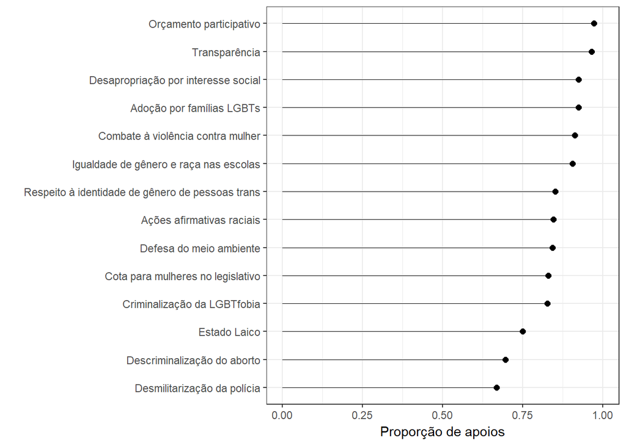

```r
por_tema =
    respostas_long %>%
    group_by(tema) %>%
    summarise(apoio = sum(resposta == "S") / n())

por_tema %>%
    ggplot(aes(x = reorder(tema, apoio), y = apoio, ymax = apoio, ymin = 0)) +
    geom_point(size = 2) +
    geom_linerange(size = .3) +
    scale_y_continuous(limits = c(0, 1)) +
    coord_flip() +
    labs(
        y = "Proporção de apoios",
        x = ""
    )
```

# 1. Em geral, candidatos que não apoiam estado laico também não apoiam a descriminalização do aborto?

### Para responder essa pergunta, irei pegar os candidatos que votaram não para o estado laico na descriminalização do aborto.

```r
contra_estado_laico =
    respostas %>%
    filter(`Estado Laico` %in% c("N")) %>%
    gather(key = "tema",
           value = "resposta",
           10:23) %>%
    group_by(tema)  %>%
    filter(tema %in% c("Descriminalização do aborto")) %>%
    summarise(apoio = sum(resposta == "S") / n())


ggplotly(ggplot(data=contra_estado_laico, aes(x = reorder(tema, apoio), y = apoio, ymax = apoio, ymin = 0)) +
    geom_point(size = 2) +
    geom_linerange(size = .3) +
    scale_y_continuous(limits = c(0, 1)) +
    coord_flip() +
    labs(
        y = "Proporção de apoios dos contra o estado laico",
        x = ""
    ))
```

```
## We recommend that you use the dev version of ggplot2 with `ggplotly()`
## Install it with: `devtools::install_github('hadley/ggplot2')`
```

[interactive chart not shown]

Mais da metade dos que disseram não ao estado laico, também disseram não para a descriminalização do aborto, isso se deve ao fato de que o aborto é uma prática que vai de encontro aos ensinamentos cristãs em que toda vida só pode ser tirada por Deus, e o ser humano não deve interferir nisso.

# 1.1. E em relação as causas LGBT, os candidatos que não apoiam estado laico também não as apoiam?

### Para responder essa pergunta, irei pegar os candidatos que votaram não para o estado laico nas causas LGBT’s

```r
contra_estado_laico =
    respostas %>%
    filter(`Estado Laico` %in% c("N")) %>%
    gather(key = "tema",
           value = "resposta",
           10:23) %>%
    group_by(tema)  %>%
    filter(tema %in% c("Adoção por famílias LGBTs","Criminalização da LGBTfobia","Respeito à identidade de gênero de pessoas trans")) %>%
    summarise(apoio = sum(resposta == "S") / n())


ggplotly(ggplot(data=contra_estado_laico,aes(x = reorder(tema, apoio), y = apoio, color=tema ,ymax = apoio, ymin = 0))+
    geom_point(size = 2) +
    geom_linerange(size = .3) +
    scale_y_continuous(limits = c(0, 1)) +
    coord_flip() +
    labs(
        y = "Proporção de apoios dos contra o estado laico",
        x = ""
    ))
```

```
## We recommend that you use the dev version of ggplot2 with `ggplotly()`
## Install it with: `devtools::install_github('hadley/ggplot2')`
```

[interactive chart not shown]

Em relação as causas LGBT’s as proporções dos que apoiam as causas, mesmo sendo contra o estado laico, são altas, a maioria disseram sim para as causas LGBT’s.

# 2. Agora observações em relação aos candidatos de um certo gênero ou raça. Candidatos com raça preta tende a apoiar mais temas relacionado á preconceitos raciais?

### Para responder essa pergunta irei selecionar todos os candidatos de raça preta, e checar a proporção das respostas para as questões raciais.

```r
raca_preta =
    respostas %>%
    filter(cor_tse %in% c("PRETA")) %>%
    gather(key = "tema",
           value = "resposta",
           10:23) %>%
    group_by(tema)  %>%
    filter(tema %in% c("Igualdade de gênero e raça nas escolas","Ações afirmativas raciais")) %>%
    summarise(apoio = sum(resposta == "S") / n(),
              naoapoio = sum(resposta=="N") / n())

plot_ly(data= raca_preta, x = ~tema, y = ~apoio, type = 'bar', name = 'Apoiam') %>%
  add_trace(y = ~naoapoio, name = 'Não apoiam') %>%
  layout(yaxis = list(title = 'Proporção'), barmode = 'group')
```

[interactive chart not shown]

Nota-se que boa parte(90%) dos candidatos de cor PRETA apoiam as causas raciais, porém esse valor poderia ser 100% já que os candidatos estão apoiando as causas de sua própria raça/etnia.

# 2.2. E as candidatas do gênero feminino, apoiam os temas relacionados ao gênero?

### Para responder essa pergunta, irei pegar a proporção de mulheres que apoiam os assuntos relacionados a gênero.

```r
mulheres =
    respostas %>%
    filter(genero %in% c("FEMININO")) %>%
    gather(key = "tema",
           value = "resposta",
           10:23) %>%
    group_by(tema)  %>%
    filter(tema %in% c("Igualdade de gênero e raça nas escolas","Combate à violência contra mulher","Cota para mulheres no legislativo")) %>%
    summarise(apoio = sum(resposta == "S") / n(),
              naoapoio = sum(resposta=="N") / n())

plot_ly(data= mulheres, x = ~tema, y = ~apoio, type = 'bar', name = 'Apoiam') %>%
  add_trace(y = ~naoapoio, name = 'Não apoiam') %>%
  layout(yaxis = list(title = 'Proporção'), barmode = 'group')
```

[interactive chart not shown]

Maior parte das candidatas do gênero feminino apoiam os assuntos ligados a gênero, sendo que o de maior apoio é no tema Igualdade de gênero. O tema de menor apoio (91%) é o de cota para mulheres no legislativo, mesmo sendo o de menor apoio ainda tem grande proporção, e demonstra que as mulheres estão buscando cada vez mais espaço e poder de voz na política.